# R Notebook

HITO5 - GRUPO 2 - ANALISIS FACTORIAL EXPLORATORIO SIN VARIABLE DESEMPLEO

```r
library(rio)
link='https://github.com/DanaeNorah/Estadistica-para-el-Analisis-Politico-2-/raw/master/TRABAJO/Base%20Final/basefinal.csv'
data = import(link)
summary(data)
```

```
##      Pais           DesigualdadGenero  MLAutonomia      MLViolencia
##  Length:196         Min.   :0.0400    Min.   :0.0000   Min.   :0.2500
##  Class :character   1st Qu.:0.1725    1st Qu.:0.0000   1st Qu.:0.5000
##  Mode  :character   Median :0.3700    Median :0.5000   Median :0.7500
##                     Mean   :0.3505    Mean   :0.4172   Mean   :0.6036
##                     3rd Qu.:0.4975    3rd Qu.:0.7500   3rd Qu.:0.7500
##                     Max.   :0.8300    Max.   :1.0000   Max.   :1.0000
##                     NA's   :34        NA's   :27       NA's   :27
##   VozPolitica     LibertadMov     ConfianzaSJ     SecundariaC
##  Min.   : 0.00   Min.   :29.70   Min.   :23.20   Min.   :  1.74
##  1st Qu.:16.00   1st Qu.:57.90   1st Qu.:47.33   1st Qu.: 37.44
##  Median :21.90   Median :65.40   Median :52.35   Median : 66.92
##  Mean   :23.54   Mean   :63.49   Mean   :51.56   Mean   : 61.49
##  3rd Qu.:31.85   3rd Qu.:70.20   3rd Qu.:57.50   3rd Qu.: 88.61
##  Max.   :61.30   Max.   :91.10   Max.   :68.10   Max.   :100.00
##  NA's   :57      NA's   :57      NA's   :58      NA's   :30
##   DesempleoMuj       CuentaF
##  Min.   : 0.380   Min.   :  1.67
##  1st Qu.: 0.970   1st Qu.: 29.94
##  Median : 1.170   Median : 52.71
##  Mean   : 1.482   Mean   : 55.11
##  3rd Qu.: 1.525   3rd Qu.: 80.83
##  Max.   :11.670   Max.   :100.00
##  NA's   :17       NA's   :41
```

```r
row.names(data)=data$Pais
data=na.omit(data)
```

###variable MLAutonomia

```r
library(car)
data$MLAutonomia <-as.factor(data$MLAutonomia)
data$MLAutonomia=factor(data$MLAutonomia,
                            levels = levels(data$MLAutonomia),
                            labels = c("1","2","3","4","5"),
                            ordered = T)
data$MLAutonomia <-as.numeric(data$MLAutonomia)
table(data$MLAutonomia)
```

```
##
##  1  2  3  4  5
## 48 15 19 30  9
```

###Variable MLViolencia

```r
#Le asignamos etiquetas a los valores
data$MLViolencia <-as.factor(data$MLViolencia)
data$MLViolencia=factor(data$MLViolencia,
                            levels = levels(data$MLViolencia),
                            labels = c("1","2","3"),
                            ordered = T)
data$MLViolencia <-as.numeric(data$MLViolencia)
table(data$MLViolencia)
```

```
##
##  1  2  3
## 29 29 63
```

PASO 0: ALISTAR BASE DE DATOS

###Creo una base de datos con las variables que usare

```r
names(data)[7]='DesconfianzaSJ'
subdata= data[,c(3,4,5,6,7,8,10)]
```

###Preparamos la subdata para la factorizacion

```r
subdata$SecundariaC= 100 - subdata$SecundariaC
subdata$CuentaF= 100 - subdata$CuentaF
subdata$VozPolitica= 100 - subdata$VozPolitica
```

###Resumen de data

```r
str(subdata)
```

```
## 'data.frame':    121 obs. of  7 variables:
##  $ MLAutonomia   : num  4 1 4 3 1 1 1 1 4 1 ...
##  $ MLViolencia   : num  3 2 2 3 3 3 1 3 3 3 ...
##  $ VozPolitica   : num  72.3 72.1 74.2 61.1 81.9 71.3 65.6 83.2 79.7 65.5 ...
##  $ LibertadMov   : num  62 70.2 58.6 61.3 58.9 78 50.9 66.7 66.9 67.9 ...
##  $ DesconfianzaSJ: num  65.2 54.5 48 54.1 52.9 59 49.3 42.2 50.6 54.6 ...
##  $ SecundariaC   : num  86.78 6.49 60.92 33.5 3.13 ...
##  $ CuentaF       : num  92.8 61.9 70.7 49.2 59.1 ...
```

PASO 1: Calculemos matriz de correlación:

```r
# esta es:
library(polycor)
corMatrix=polycor::hetcor(subdata)$correlations
```

2. Explorar correlaciones:

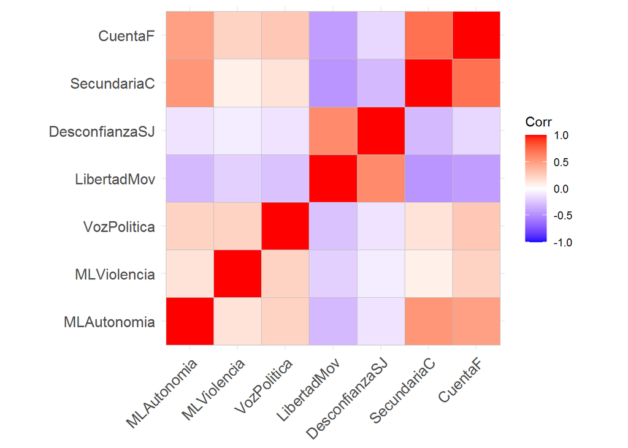

```r
#Sin evaluar significancia:
library(ggcorrplot)
ggcorrplot(corMatrix)
```

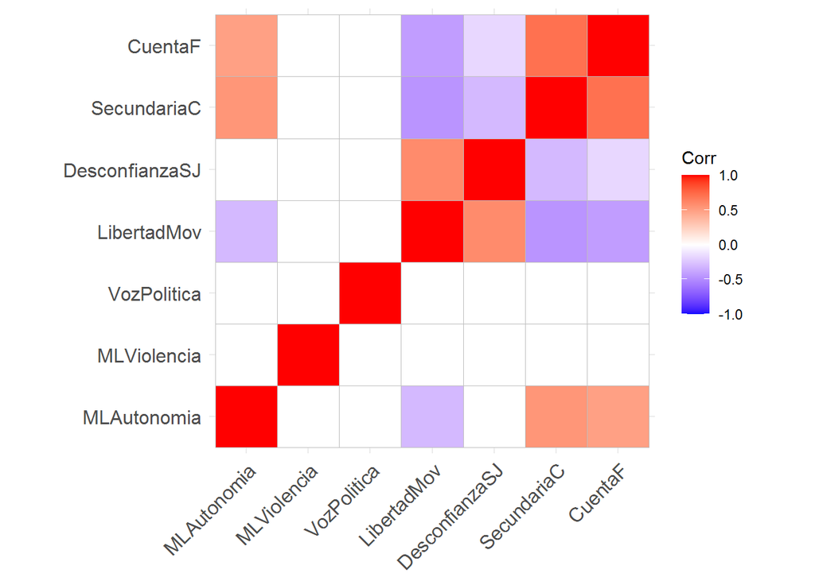

```r
#Evaluando significancia:
ggcorrplot(corMatrix,
          p.mat = cor_pmat(corMatrix),
          insig = "blank")
```

```r
#te sirve para redondear a dos decimales, pero si se corresolo "matriz_corr" es para sacar
round(corMatrix, 2)
```

```
##                MLAutonomia MLViolencia VozPolitica LibertadMov DesconfianzaSJ
## MLAutonomia           1.00        0.15        0.23       -0.30          -0.12
## MLViolencia           0.15        1.00        0.23       -0.20          -0.08
## VozPolitica           0.23        0.23        1.00       -0.26          -0.12
## LibertadMov          -0.30       -0.20       -0.26        1.00           0.59
## DesconfianzaSJ       -0.12       -0.08       -0.12        0.59           1.00
## SecundariaC           0.54        0.08        0.15       -0.46          -0.30
## CuentaF               0.49        0.23        0.29       -0.42          -0.17
##                SecundariaC CuentaF
## MLAutonomia           0.54    0.49
## MLViolencia           0.08    0.23
## VozPolitica           0.15    0.29
## LibertadMov          -0.46   -0.42
## DesconfianzaSJ       -0.30   -0.17
## SecundariaC           1.00    0.71
## CuentaF               0.71    1.00
```

3. Verificar si datos permiten factorizar:

```r
library(psych)
psych::KMO(corMatrix)
```

```
## Kaiser-Meyer-Olkin factor adequacy
## Call: psych::KMO(r = corMatrix)
## Overall MSA =  0.7
## MSA for each item =
##    MLAutonomia    MLViolencia    VozPolitica    LibertadMov DesconfianzaSJ
##           0.83           0.66           0.73           0.72           0.60
##    SecundariaC        CuentaF
##           0.67           0.70
```

4. Verificar si la matriz de correlaciones es adecuada
   - Aqui hay dos pruebas:
1. Hnula: La matriz de correlacion es una matriz identidad

```r
cortest.bartlett(corMatrix,n=nrow(subdata))$p.value>0.05
```

```
## [1] FALSE
```

2. Hnula: La matriz de correlacion es una matriz singular.

```r
library(matrixcalc)
is.singular.matrix(corMatrix)
```

```
## [1] FALSE
```

5, Determinar en cuantos factores o variables latentes podríamos redimensionar la subdata:

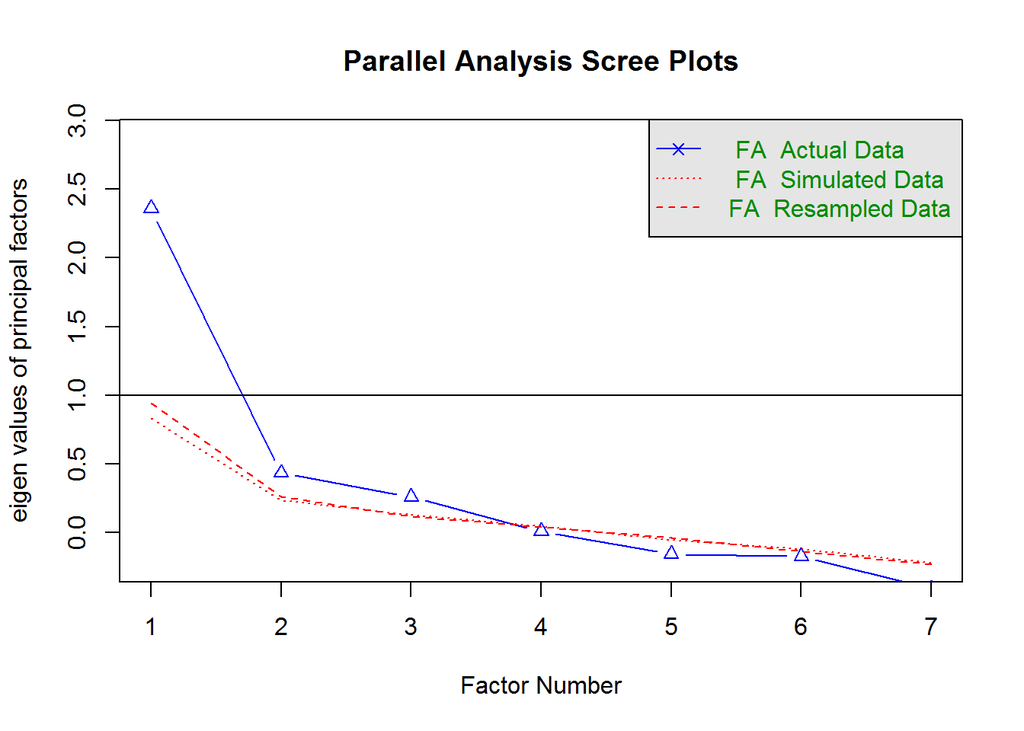

```
## Parallel analysis suggests that the number of factors =  3  and the number of components =  NA
```

```r
fa.parallel(subdata,fm = 'ML', fa = 'fa')
```

6. Redimensionar a numero menor de factores

Resultado inicial:

```r
library(GPArotation)
resfa <- fa(subdata,nfactors = 3,cor = 'mixed',rotate = "varimax",fm="minres")
print(resfa$loadings)
```

```
##
## Loadings:
##                MR1    MR2    MR3
## MLAutonomia     0.601         0.275
## MLViolencia                   0.493
## VozPolitica     0.147         0.500
## LibertadMov    -0.321  0.619 -0.317
## DesconfianzaSJ         0.885
## SecundariaC     0.964 -0.258
## CuentaF         0.716 -0.110  0.371
##
##                  MR1   MR2   MR3
## SS loadings    1.941 1.263 0.810
## Proportion Var 0.277 0.180 0.116
## Cumulative Var 0.277 0.458 0.574
```

RESPUESTA: 57.4% de las caracteristicas de las variables,es un problema porque se pierde bastante información.No se utiliza el EFA.

Resultado mejorado:

```r
print(resfa$loadings,cutoff = 0.5)
```

```
##
## Loadings:
##                MR1    MR2    MR3
## MLAutonomia     0.601
## MLViolencia
## VozPolitica                   0.500
## LibertadMov            0.619
## DesconfianzaSJ         0.885
## SecundariaC     0.964
## CuentaF         0.716
##
##                  MR1   MR2   MR3
## SS loadings    1.941 1.263 0.810
## Proportion Var 0.277 0.180 0.116
## Cumulative Var 0.277 0.458 0.574
```

Cuando logramos que cada variable se vaya a un factor, tenemos una estructura simple.

Resultado visual:

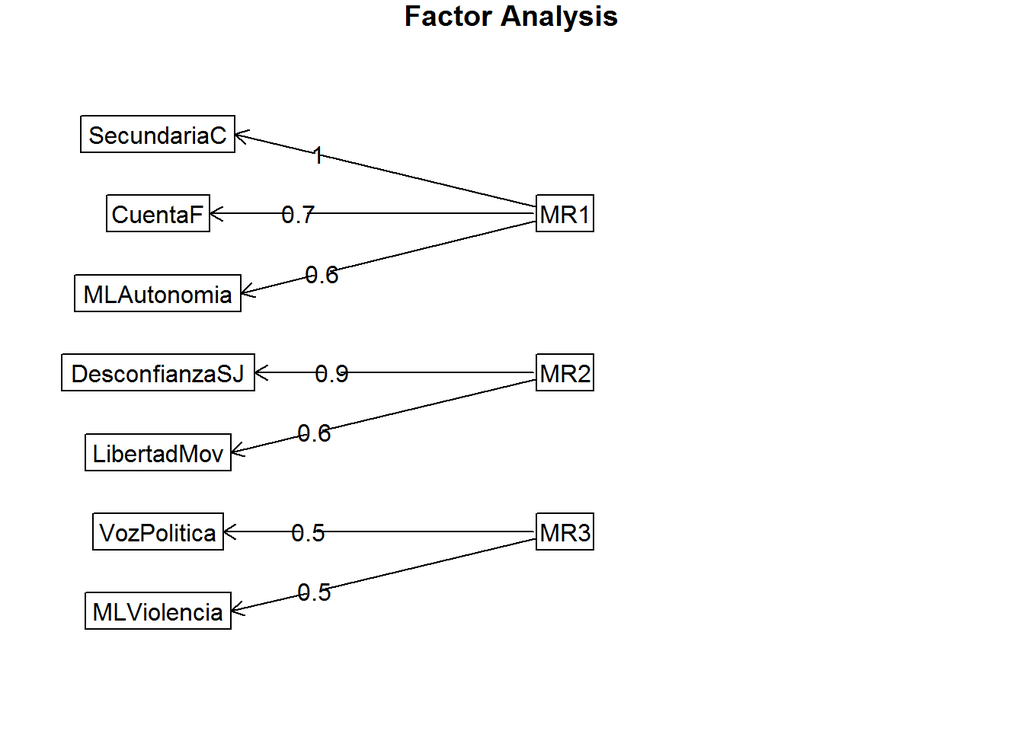

```r
fa.diagram(resfa)
```

CONCLUSION: los tres factores obtenidos en el análisis factorial no corresponde a las variables latentes propuestas segun la revision de literatura.

7. Evaluando Resultado obtenido:

```r
#¿La Raíz del error cuadrático medio corregida está cerca a cero?
resfa$crms
```

```
## [1] 0.0209319
```

```r
#¿La Raíz del error cuadrático medio de aproximación es menor a 0.05?
resfa$RMSEA
```

```
##      RMSEA      lower      upper confidence
## 0.00000000 0.00000000 0.04573981 0.90000000
```

```r
#¿El índice de Tucker-Lewis es mayor a 0.9?
resfa$TLI
```

```
## [1] 1.076173
```

```r
#¿Qué variables aportaron mas a los factores?
sort(resfa$communality)
```

```
##    MLViolencia    VozPolitica    MLAutonomia    LibertadMov        CuentaF
##      0.2554618      0.2799445      0.4422439      0.5862247      0.6616831
## DesconfianzaSJ    SecundariaC
##      0.7917993      0.9971893
```

```r
#¿Qué variables contribuyen a mas de un factor?
sort(resfa$complexity)
```

```
## DesconfianzaSJ    MLViolencia    SecundariaC    VozPolitica    MLAutonomia
##       1.023625       1.104337       1.144127       1.238928       1.436226
##        CuentaF    LibertadMov
##       1.555829       2.056408
```

8.Posibles valores proyectados:

Creamos un data set

```r
factoriales=as.data.frame(resfa$scores)
head(factoriales)
```

|  | MR1 | MR2 | MR3 |
| --- | --- | --- | --- |
| Afghanistan | 2.04388942 | 1.4867070 | 0.3656101 |
| Albania | -1.05248631 | 0.4725919 | 0.4849674 |
| Algeria | 0.70884915 | -0.3211092 | 0.1816551 |
| Argentina | -0.09313593 | 0.2184054 | 0.2812373 |
| Armenia | -1.23661197 | 0.1058787 | 1.3657410 |
| Australia | -0.81663657 | 0.8450793 | -0.4398838 |

o incluirlos en nuestro subset original

```r
subdata$factor1<- factoriales$MR1
subdata$factor2<- factoriales$MR2
subdata$factor3<- factoriales$MR3

summary(factoriales)
```

```
##       MR1                MR2               MR3
##  Min.   :-1.62478   Min.   :-3.1857   Min.   :-2.112250
##  1st Qu.:-0.91840   1st Qu.:-0.5262   1st Qu.:-0.455124
##  Median :-0.09314   Median : 0.0981   Median : 0.009348
##  Mean   : 0.00000   Mean   : 0.0000   Mean   : 0.000000
##  3rd Qu.: 0.88617   3rd Qu.: 0.6507   3rd Qu.: 0.502905
##  Max.   : 2.04389   Max.   : 1.5673   Max.   : 1.536581
```

9. REINCORPORAMOS AL SUBDATA LAS VARIABLES QUE SE NECESITAN PARA LA REGRESION (PAIS,DESIGUALDADDEGENERO Y DESEMPELO MUJ)

```r
subdata=cbind(data[,c(1,2,9)],subdata)
```

10. NORMALIZAMOS LOS FACTORES Y NUESTRO INDICE DE DESIGUALDAD DE GENERO

```r
library(BBmisc)
subdata$DesigualdadGenero=normalize(subdata$DesigualdadGenero,
                      method = "range",
                      margin=2, # by column
                      range = c(0, 100))
subdata$factor1=normalize(subdata$factor1,
                      method = "range",
                      margin=2, # by column
                      range = c(0, 100))
subdata$factor2=normalize(subdata$factor2,
                      method = "range",
                      margin=2, # by column
                      range = c(0, 100))
subdata$factor3=normalize(subdata$factor3,
                      method = "range",
                      margin=2, # by column
                      range = c(0, 100))
```

añadir correlaciones con cada factor independiente

```r
f1=formula(~DesigualdadGenero + factor1) #v. dependiente y v. independiente
# camino parametrico
pearson1=cor.test(f1,data=subdata)
pearson1
```

```
##
##  Pearson's product-moment correlation
##
## data:  DesigualdadGenero and factor1
## t = 15.325, df = 119, p-value < 2.2e-16
## alternative hypothesis: true correlation is not equal to 0
## 95 percent confidence interval:
##  0.7444445 0.8670906
## sample estimates:
##       cor
## 0.8146851
```

```r
f2=formula(~DesigualdadGenero + factor2) #v. dependiente y v. independiente
# camino parametrico
pearson2=cor.test(f2,data=subdata)
pearson2
```

```
##
##  Pearson's product-moment correlation
##
## data:  DesigualdadGenero and factor2
## t = -1.9551, df = 119, p-value = 0.05291
## alternative hypothesis: true correlation is not equal to 0
## 95 percent confidence interval:
##  -0.344078096  0.002147669
## sample estimates:
##        cor
## -0.1764165
```

```r
f3=formula(~DesigualdadGenero + factor3) #v. dependiente y v. independiente
# camino parametrico
pearson3=cor.test(f3,data=subdata)
pearson3
```

```
##
##  Pearson's product-moment correlation
##
## data:  DesigualdadGenero and factor3
## t = 4.4919, df = 119, p-value = 1.645e-05
## alternative hypothesis: true correlation is not equal to 0
## 95 percent confidence interval:
##  0.2170085 0.5236628
## sample estimates:
##       cor
## 0.3807563
```

11. GRAIFCAS DE LAS CORRELACIONES

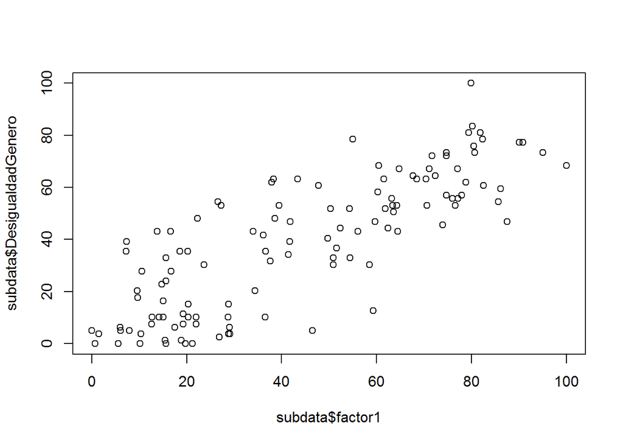

```r
plot(subdata$factor1,subdata$DesigualdadGenero)
```

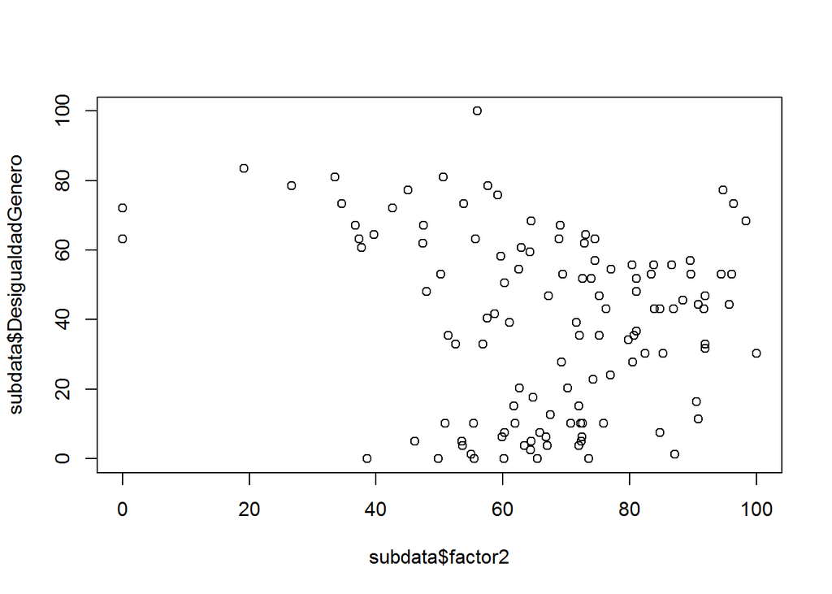

```r
plot(subdata$factor2,subdata$DesigualdadGenero)
```

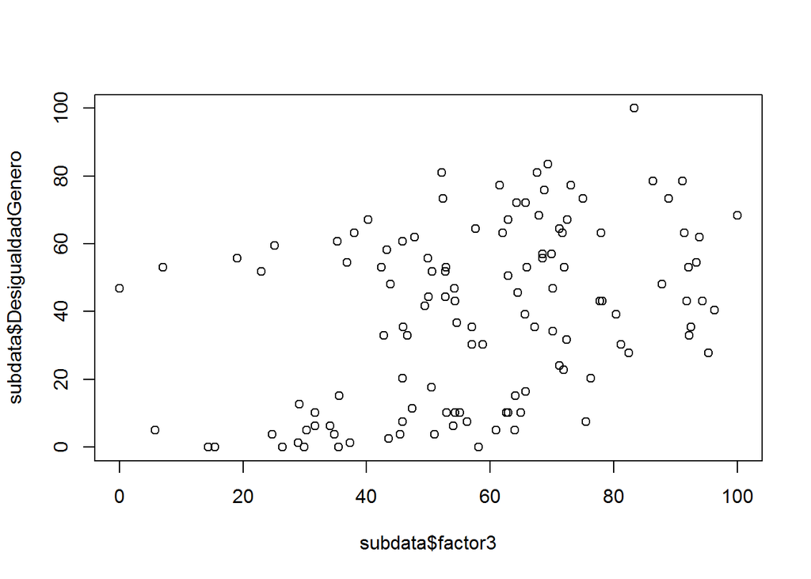

```r
plot(subdata$factor3,subdata$DesigualdadGenero)
```

#REGRESIONES

```r
hipotesis1= formula(DesigualdadGenero ~ factor1)
regresion1=lm(hipotesis1,data=subdata)
summary(regresion1)
```

```
##
## Call:
## lm(formula = hipotesis1, data = subdata)
##
## Residuals:
##     Min      1Q  Median      3Q     Max
## -37.890 -10.655  -2.294   9.767  33.627
##
## Coefficients:
##             Estimate Std. Error t value Pr(>|t|)
## (Intercept)  5.07145    2.59665   1.953   0.0532 .
## factor1      0.76727    0.05007  15.325   <2e-16 ***
## ---
## Signif. codes:  0 '***' 0.001 '**' 0.01 '*' 0.05 '.' 0.1 ' ' 1
##
## Residual standard error: 14.86 on 119 degrees of freedom
## Multiple R-squared:  0.6637, Adjusted R-squared:  0.6609
## F-statistic: 234.9 on 1 and 119 DF,  p-value: < 2.2e-16
```

```r
hipotesis2 = formula(DesigualdadGenero ~ factor3)
regresion2=lm(hipotesis2,data=subdata)
summary(regresion2)
```

```
##
## Call:
## lm(formula = hipotesis2, data = subdata)
##
## Residuals:
##     Min      1Q  Median      3Q     Max
## -39.382 -21.603  -1.068  21.087  49.503
##
## Coefficients:
##             Estimate Std. Error t value Pr(>|t|)
## (Intercept)  12.9439     6.1988   2.088   0.0389 *
## factor3       0.4510     0.1004   4.492 1.65e-05 ***
## ---
## Signif. codes:  0 '***' 0.001 '**' 0.01 '*' 0.05 '.' 0.1 ' ' 1
##
## Residual standard error: 23.7 on 119 degrees of freedom
## Multiple R-squared:  0.145,  Adjusted R-squared:  0.1378
## F-statistic: 20.18 on 1 and 119 DF,  p-value: 1.645e-05
```

```r
hipotesis3 = formula(DesigualdadGenero ~ factor1 + factor3)
regresion3=lm(hipotesis3,data=subdata)
summary(regresion3)
```

```
##
## Call:
## lm(formula = hipotesis3, data = subdata)
##
## Residuals:
##     Min      1Q  Median      3Q     Max
## -24.680  -6.816  -1.289   7.777  32.435
##
## Coefficients:
##              Estimate Std. Error t value Pr(>|t|)
## (Intercept) -21.77703    3.34631  -6.508 1.93e-09 ***
## factor1       0.77102    0.03728  20.681  < 2e-16 ***
## factor3       0.46093    0.04689   9.830  < 2e-16 ***
## ---
## Signif. codes:  0 '***' 0.001 '**' 0.01 '*' 0.05 '.' 0.1 ' ' 1
##
## Residual standard error: 11.07 on 118 degrees of freedom
## Multiple R-squared:  0.8151, Adjusted R-squared:  0.812
## F-statistic: 260.1 on 2 and 118 DF,  p-value: < 2.2e-16
```

```r
hipotesis4 = formula(DesigualdadGenero ~ factor1 + factor2 + factor3)
regresion4=lm(hipotesis4,data=subdata[,-c(1)])
summary(regresion4)
```

```
##
## Call:
## lm(formula = hipotesis4, data = subdata[, -c(1)])
##
## Residuals:
##     Min      1Q  Median      3Q     Max
## -24.777  -6.913  -0.137   5.525  29.517
##
## Coefficients:
##              Estimate Std. Error t value Pr(>|t|)
## (Intercept) -11.60950    4.99142  -2.326  0.02175 *
## factor1       0.76538    0.03639  21.031  < 2e-16 ***
## factor2      -0.14063    0.05226  -2.691  0.00817 **
## factor3       0.45243    0.04581   9.877  < 2e-16 ***
## ---
## Signif. codes:  0 '***' 0.001 '**' 0.01 '*' 0.05 '.' 0.1 ' ' 1
##
## Residual standard error: 10.79 on 117 degrees of freedom
## Multiple R-squared:  0.8259, Adjusted R-squared:  0.8214
## F-statistic:   185 on 3 and 117 DF,  p-value: < 2.2e-16
```

```r
library(stargazer)
stargazer(regresion3, regresion4, type = "text")
```

```
##
## =====================================================================
##                                    Dependent variable:
##                     -------------------------------------------------
##                                     DesigualdadGenero
##                               (1)                      (2)
## ---------------------------------------------------------------------
## factor1                     0.771***                 0.765***
##                             (0.037)                  (0.036)
##
## factor2                                             -0.141***
##                                                      (0.052)
##
## factor3                     0.461***                 0.452***
##                             (0.047)                  (0.046)
##
## Constant                   -21.777***               -11.609**
##                             (3.346)                  (4.991)
##
## ---------------------------------------------------------------------
## Observations                  121                      121
## R2                           0.815                    0.826
## Adjusted R2                  0.812                    0.821
## Residual Std. Error    11.068 (df = 118)        10.787 (df = 117)
## F Statistic         260.123*** (df = 2; 118) 184.999*** (df = 3; 117)
## =====================================================================
## Note:                                     *p<0.1; **p<0.05; ***p<0.01
```

#agregamos desmepleo como variable CONTROL (PONER EN ANEXO)

```r
hipotesis5 = formula(DesigualdadGenero ~ factor1 + factor2 + factor3+ DesempleoMuj)
regresion5=lm(hipotesis5,data=subdata[,-c(1)])
summary(regresion5)
```

```
##
## Call:
## lm(formula = hipotesis5, data = subdata[, -c(1)])
##
## Residuals:
##      Min       1Q   Median       3Q      Max
## -24.5372  -6.9517  -0.2169   5.2816  29.4610
##
## Coefficients:
##               Estimate Std. Error t value Pr(>|t|)
## (Intercept)  -12.33327    5.55770  -2.219  0.02842 *
## factor1        0.76158    0.03865  19.706  < 2e-16 ***
## factor2       -0.13992    0.05252  -2.664  0.00882 **
## factor3        0.44946    0.04703   9.558 2.58e-16 ***
## DesempleoMuj   0.82121    2.72749   0.301  0.76389
## ---
## Signif. codes:  0 '***' 0.001 '**' 0.01 '*' 0.05 '.' 0.1 ' ' 1
##
## Residual standard error: 10.83 on 116 degrees of freedom
## Multiple R-squared:  0.826,  Adjusted R-squared:   0.82
## F-statistic: 137.7 on 4 and 116 DF,  p-value: < 2.2e-16
```

#DIAGNOSTICO DE LA REGRESION CON LOS FACTORES - Para que se considere que el modelo de regresión elegido es el adecuado, debemos verificar algunos requisitos a posteriori: 1. Linealidad: - Se asume relación lineal entre Y y X:

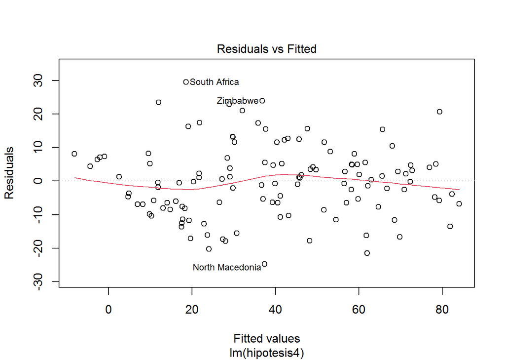

```r
# linea roja debe tender a horizontal
plot(regresion4, 1)
```

2. Homocedasticidad